# Project: Investigate a Dataset - [IMDb Movie Dataset]

### Research Question 3 (Which Genre attracts the people the most?)

SPLIT THE GENRES INTO 5 COLUMNS SO WE CAN HAVE A CLEAR ANALYSIS

```python
genres_split = df['genres'].str.split('|', expand=True)
```

NAME THE COLUMNS

```python
genres_split.columns = [f'genre_{i+1}' for i in range(genres_split.shape[1])]

#CONCAT
df1 = pd.concat([df, genres_split], axis=1)

df1.head()

df1['genre_1'].value_counts()
genre_stats = df1.groupby('genre_1').agg({
    'revenue': 'mean',
    'popularity': 'mean',
    'vote_average': 'mean'
})
#PRINT GENRE STATISTICS FOR EACH GENRE
print("Genre Statistics:")
print(genre_stats.sort_values('revenue', ascending=False))
```

```
Genre Statistics:
                      revenue  popularity  vote_average
genre_1
Adventure        1.328017e+08    1.277373      6.071636
Science Fiction  8.697144e+07    1.156476      5.894388
Animation        8.332929e+07    0.897450      6.398261
Fantasy          7.232828e+07    0.911306      5.804743
Family           6.917541e+07    0.783861      5.951562
Action           6.528229e+07    0.876155      5.764479
History          5.004788e+07    0.839363      6.343590
War              4.751845e+07    0.789277      6.191228
Romance          4.375474e+07    0.786560      6.156522
Crime            3.519547e+07    0.719750      6.229917
Comedy           3.257873e+07    0.572296      5.872121
Western          3.109095e+07    0.690646      6.080952
Music            2.917235e+07    0.528743      6.436709
Drama            2.770208e+07    0.587367      6.219163
Thriller         2.743306e+07    0.691054      5.640084
Mystery          2.559222e+07    0.621116      5.926271
Horror           1.804527e+07    0.487790      5.357093
Documentary      3.015843e+06    0.211205      6.944318
TV Movie         7.118644e+05    0.268062      5.654237
Foreign          0.000000e+00    0.232168      5.600000
```

```python
df1['genre_1'].value_counts()
```

```
Drama              2223
Comedy             2084
Action             1478
Horror              853
Adventure           550
Thriller            474
Crime               361
Animation           345
Documentary         264
Fantasy             253
Science Fiction     196
Romance             161
Family              128
Mystery             118
Music                79
TV Movie             59
War                  57
Western              42
History              39
Foreign               6
Name: genre_1, dtype: int64
```

```python
#to identify the highest rated drama movie
drama=df1[df1['genre_1']=='Drama']
max_movie_rat=drama[drama['vote_average']==8.4]
max_movie_rat
```

|  | id | imdb_id | popularity | budget | revenue | original_title | cast | homepage | director | tagline | ... | vote_count | vote_average | release_year | budget_adj | revenue_adj | genre_1 | genre_2 | genre_3 | genre_4 | genre_5 |
| --- | --- | --- | --- | --- | --- | --- | --- | --- | --- | --- | --- | --- | --- | --- | --- | --- | --- | --- | --- | --- | --- |
| 4178 | 278 | tt0111161 | 7.192039 | 25000000 | 28341469 | The Shawshank Redemption | Tim Robbins\|Morgan Freeman\|Bob Gunton\|William ... | NaN | Frank Darabont | Fear can hold you prisoner. Hope can set you f... | ... | 5754 | 8.4 | 1994 | 3.677779e+07 | 4.169346e+07 | Drama | Crime | None | None | None |
| 5986 | 242575 | tt2876428 | 0.054380 | 4000000 | 0 | Guten Tag, Ramón | Adriana Barraza\|Rüdiger Evers\|Hector Kotsifak... | NaN | Jorge Ramírez Suárez | NaN | ... | 11 | 8.4 | 2013 | 3.744133e+06 | 0.000000e+00 | Drama | None | None | None | None |

2 rows × 26 columns

COMPARISON BETWEEN THE AMOUNT OF FILMS FOR EACH GENRE THROGH HISTOGRAM

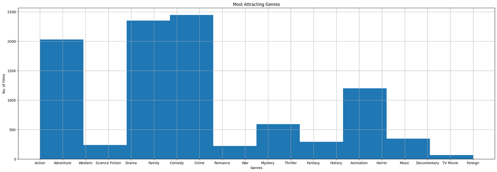

```python
df1['genre_1'].hist(figsize=(25,8));
label_plot('Most Attracting Genres','Genres','No. of Films')
```

- The genre with the largest amount of films is [Drama] with a no. of [2223] films
- The highest rated Drama movie is [The Shawshank Redemption] released in 1994 & [Guten Tag] released in 2013.

HIGHEST EARNING GENRES

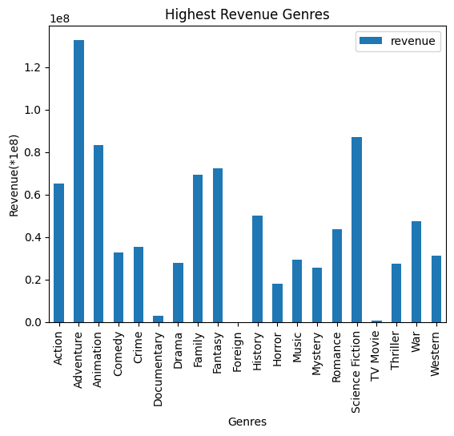

```python
genre_stats.plot(y='revenue',kind='bar')
label_plot('Highest Revenue Genres','Genres','Revenue(*1e8)')
```

This bar plot shows the average revenue gained by each genre.

The Adventure genre is th one with the highest revenue average.

It's average revenue is equal to 1.328017e+08

HIGHEST RATING GENRES

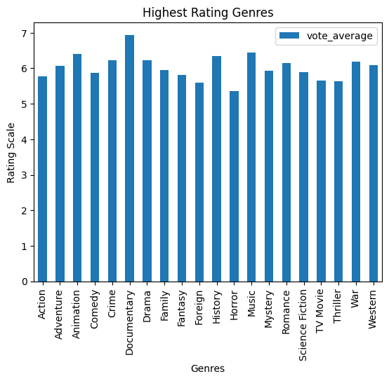

```python
genre_stats.plot(y='vote_average',kind='bar')
label_plot('Highest Rating Genres','Genres','Rating Scale')
```

This bar plot shows the average rating of each genre.

The Documentary genre is th one with the highest average rating.

### Research Question 4 (Which time of the year is most preferable to release a film?)

NOW, WE NEED TO DIVIDE THE release_date INTO THREE COLUMNS:

```python
release_dates=df1['release_date'].str.split('/',expand=True)

df1 = pd.concat([df1, release_dates], axis=1)


df1.head()
df1.rename(columns={0: 'quarter', 1: 'day', 2: 'year'}, inplace=True)
```

DEFINING A METHOD TO DIVIDE THE MONTHS OF THE YEAR ACCROSS THE 4 QUARTERS.

```python
def dividing_to_quarters(column,quarter,month1,month2,month3):
    df1[column] = np.where(df1[column].isin([month1, month2, month3]), quarter , df1[column])
```

DEFINING THE MONTHS OF THE YEAR INTO THE 4 QUARTERS

```python
df1['quarter']=df1['quarter'].replace({'1':'Q1','2':'Q1','3':'Q1'})

dividing_to_quarters('quarter','Q2','4','5','6')
dividing_to_quarters('quarter','Q3','7','8','9')
dividing_to_quarters('quarter','Q4','10','11','12')

df1.head()
# I decided to divided into quarters to be easier to analyze what time of the year the production companies target to release their movies within
# By that, I concluded that it's better to release on the 3rd quarter where the traffic is the highest.
```

|  | id | imdb_id | popularity | budget | revenue | original_title | cast | homepage | director | tagline | ... | budget_adj | revenue_adj | genre_1 | genre_2 | genre_3 | genre_4 | genre_5 | quarter | day | year |
| --- | --- | --- | --- | --- | --- | --- | --- | --- | --- | --- | --- | --- | --- | --- | --- | --- | --- | --- | --- | --- | --- |
| 0 | 135397 | tt0369610 | 32.985763 | 150000000 | 1513528810 | Jurassic World | Chris Pratt\|Bryce Dallas Howard\|Irrfan Khan\|Vi... | http://www.jurassicworld.com/ | Colin Trevorrow | The park is open. | ... | 1.379999e+08 | 1.392446e+09 | Action | Adventure | Science Fiction | Thriller | None | Q2 | 9 | 15 |
| 1 | 76341 | tt1392190 | 28.419936 | 150000000 | 378436354 | Mad Max: Fury Road | Tom Hardy\|Charlize Theron\|Hugh Keays-Byrne\|Nic... | http://www.madmaxmovie.com/ | George Miller | What a Lovely Day. | ... | 1.379999e+08 | 3.481613e+08 | Action | Adventure | Science Fiction | Thriller | None | Q2 | 13 | 15 |
| 2 | 262500 | tt2908446 | 13.112507 | 110000000 | 295238201 | Insurgent | Shailene Woodley\|Theo James\|Kate Winslet\|Ansel... | http://www.thedivergentseries.movie/#insurgent | Robert Schwentke | One Choice Can Destroy You | ... | 1.012000e+08 | 2.716190e+08 | Adventure | Science Fiction | Thriller | None | None | Q1 | 18 | 15 |
| 3 | 140607 | tt2488496 | 11.173104 | 200000000 | 2068178225 | Star Wars: The Force Awakens | Harrison Ford\|Mark Hamill\|Carrie Fisher\|Adam D... | http://www.starwars.com/films/star-wars-episod... | J.J. Abrams | Every generation has a story. | ... | 1.839999e+08 | 1.902723e+09 | Action | Adventure | Science Fiction | Fantasy | None | Q4 | 15 | 15 |
| 4 | 168259 | tt2820852 | 9.335014 | 190000000 | 1506249360 | Furious 7 | Vin Diesel\|Paul Walker\|Jason Statham\|Michelle ... | http://www.furious7.com/ | James Wan | Vengeance Hits Home | ... | 1.747999e+08 | 1.385749e+09 | Action | Crime | Thriller | None | None | Q2 | 1 | 15 |

5 rows × 29 columns

```python
#identify the number of movies released in each quarter
df1['quarter'].value_counts()
```

```
Q3    2759
Q4    2668
Q2    2231
Q1    2112
Name: quarter, dtype: int64
```

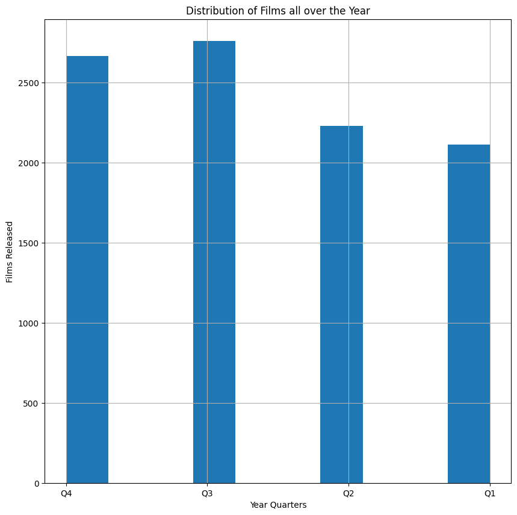

```python
quarters_descending=df1.sort_values(by='quarter',ascending=False)
quarters_descending['quarter'].hist(figsize=(10,10));
label_plot('Distribution of Films all over the Year','Year Quarters','Films Released')
```

The bar plot above shows the distribution of the films across the 4 quarter of the year. Key findings:

The quarter where the largest amount of films is released is the 3rd Quarter.

There are 2759 movies released in Q3

#### Research Question 5 (Who is the director with the most films?)

CREATING A NEW DATAFRAME WITH THE TOP MOST PRODUCING DIRECTORS

```python
#identify the no. of movies produced by each director
df1['director'].value_counts()
```

```
Woody Allen          42
Clint Eastwood       34
Steven Spielberg     29
Martin Scorsese      26
Ridley Scott         23
                     ..
Paul Bettany          1
Adam Robitel          1
Kurando Mitsutake     1
Scot Armstrong        1
Harold P. Warren      1
Name: director, Length: 4504, dtype: int64
```

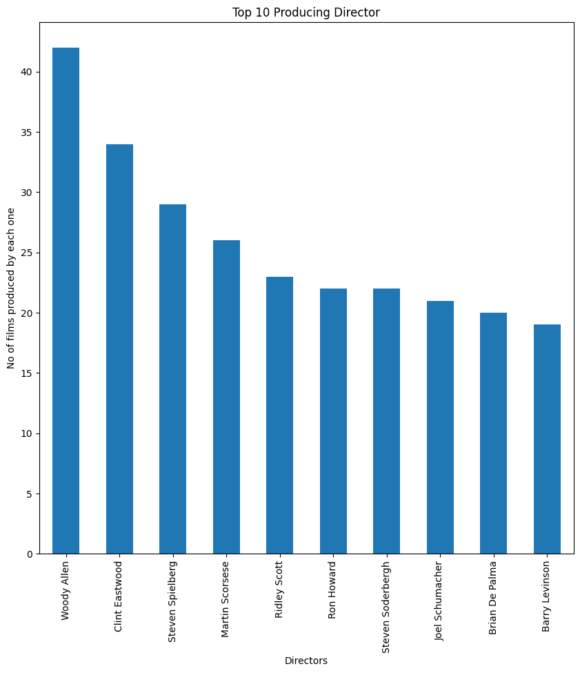

```python
top_directors=df1['director'].value_counts().head(10)
top_directors.plot(kind='bar',figsize=(10,10))
label_plot('Top 10 Producing Director','Directors','No of films produced by each one')
```

This bar plot shows the most producing directors of all time.

The Highest Producing director is Woody Allen.

He has produced 42 movies of the IMDb list of movies.

### Research Question 6 (The Variation of Rating for Each Movie Genre )

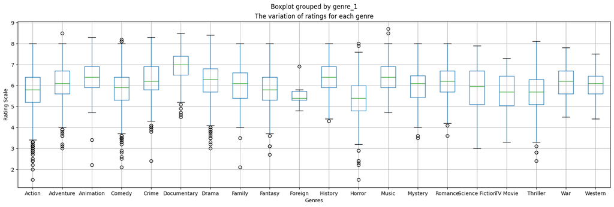

```python
df1.boxplot(column='vote_average', by='genre_1', figsize=(20, 6));
label_plot('The variation of ratings for each genre','Genres','Rating Scale')
```

```python
std_genres = df1.groupby('genre_1').agg({
    'vote_average': ['mean', 'std']
})
std_genres
```

| genre_1 | vote_average mean | vote_average std |
| --- | --- | --- |
| Action | 5.764479 | 0.937117 |
| Adventure | 6.071636 | 0.890117 |
| Animation | 6.398261 | 0.772603 |
| Comedy | 5.872121 | 0.815450 |
| Crime | 6.229917 | 0.842478 |
| Documentary | 6.944318 | 0.735239 |
| Drama | 6.219163 | 0.803745 |
| Family | 5.951562 | 0.886911 |
| Fantasy | 5.804743 | 0.904430 |
| Foreign | 5.600000 | 0.715542 |
| History | 6.343590 | 0.740482 |
| Horror | 5.357093 | 0.938389 |
| Music | 6.436709 | 0.791652 |
| Mystery | 5.926271 | 0.870154 |
| Romance | 6.156522 | 0.752478 |
| Science Fiction | 5.894388 | 1.034888 |
| TV Movie | 5.654237 | 0.950195 |
| Thriller | 5.640084 | 0.897893 |
| War | 6.191228 | 0.792212 |
| Western | 6.080952 | 0.752958 |

This boxplot shows the variation of the ratings for each genre.

The Highest Standard of variation is in the Science Fiction Genre (it means there are lots of different opinions and controversy on this genre)

He has a standard deviation of 1.034888

Comes After it TV Movie Genre with 0.950195

## Conclusions

Finally, the analysis identified the director with the highest number of films in the dataset, giving insight into which filmmakers have the most extensive output within the provided sample.

Despite these insights, the analysis has several limitations. Most importantly, the dataset may not represent the entire film industry globally, meaning that results may vary if more complete data were included. Moreover, because no statistical tests were conducted, the conclusions are descriptive rather than inferential. Additional factors—such as budgets, advertising, cultural trends, or international releases—were not examined and could influence the results. Future research could integrate larger datasets, include statistical modeling, or investigate audience demographics to provide a more comprehensive understanding of film performance.

Overall, the findings offer valuable descriptive insight into movie ratings, sales, genres, release patterns, and director outputs, while also highlighting opportunities for deeper exploration.

## Submitting your Project

```python
# Running this cell will execute a bash command to convert this notebook to an .html file
!python -m nbconvert --to html Investigate_a_Dataset.ipynb
```

```
[NbConvertApp] Converting notebook Investigate_a_Dataset.ipynb to html
```